# 09-reference-baseline-mixture-analysis

23 February 2023

Implementing the functions for reading in genos from the rds files created by microhaplot.

I used `R-main/01-compile-and-tidy-rds-files.R` to generate an rds file with the genotype info in `data/processed`.

The R function uses a minimum read depth of 10 reads for the first allele and 6 reads for the second allele and a minimum allele balance of 0.4 (this can be modified in `R/microhaplot-genos-funcs.R`).

The VCF file used to generate these rds files is `BFAL_reference_filtered.vcf`, currently on Sedna. I might return to this by merging additional samples into that VCF file, but those would be bycatch - not reference samples - and the benefit to doing so is uncertain.

```r
library(tidyverse)
library(readxl)
library(stringr)
library(lubridate)
```

```r
# read in rds file with genotypes
genos_long <- read_rds("../data/processed/called_genos_na_explicit.rds")

head(genos_long)
```

| gtseq_run | id | locus | gene_copy | allele | depth | allele.balance |
| --- | --- | --- | --- | --- | --- | --- |
| gtseq5 | s1 | scaffold_0_4543438 | 1 | GGA | 64 | 1 |
| gtseq5 | s1 | scaffold_0_4543438 | 2 | GGA | 64 | NA |
| gtseq5 | s1 | scaffold_1_5556176 | 1 | CC | 16 | 1 |
| gtseq5 | s1 | scaffold_1_5556176 | 2 | CC | 16 | NA |
| gtseq5 | s1 | scaffold_10_1333563 | 1 | A | 48 | 1 |
| gtseq5 | s1 | scaffold_10_1333563 | 2 | A | 48 | NA |

I need to vet both the loci and the individuals for missing data, etc.

## Locus evaluation

How many loci and how many alleles?

```r
# alleles
genos_long %>%
  filter(!is.na(allele)) %>%
  select(locus, allele) %>%
  unique()
```

| locus | allele |
| --- | --- |
| scaffold_0_4543438 | GGA |
| scaffold_1_5556176 | CC |
| scaffold_10_1333563 | A |
| scaffold_102_694013 | T |
| scaffold_1050_36334 | T |
| scaffold_1053_177405 | A |
| scaffold_1053_177405 | G |
| scaffold_1078_116737 | GT |
| scaffold_11_3057945 | C |
| scaffold_115_2200290 | C |

[output cut: 474 more lines]

```r
# loci
genos_long %>%
  filter(!is.na(allele)) %>%
  select(locus, allele) %>%
  unique() %>%
  group_by(locus) %>%
  tally() %>%
  arrange(desc(n))
```

| locus | n |
| --- | --- |
| scaffold_1226_115783 | 8 |
| scaffold_1589_18141 | 7 |
| scaffold_1164_119437 | 6 |
| scaffold_700_166185 | 6 |
| scaffold_925_195188 | 6 |
| scaffold_316_437138 | 5 |
| scaffold_33_2811656 | 5 |
| scaffold_343_778064 | 5 |
| scaffold_48_3128896 | 5 |
| scaffold_51_1220763 | 5 |

[output cut: 180 more lines]

```r
NA
NA
```

484 alleles across 190 loci with between 1-8 alleles per locus.

Missing data:

```r
# missing data across loci
locs_to_toss <- genos_long %>%
  group_by(locus) %>%
  mutate(missingness = ifelse(is.na(allele), 1, 0)) %>%
  summarise(sum(missingness)) %>% # 190 loci x2 = total
  filter(`sum(missingness)`>190) %>% # more than 50% missing data
  select(locus) # drop those loci for now and see how the assignment goes

# just the keepers
genos_locs_filtered <- genos_long %>%
  anti_join(., locs_to_toss)
```

```r
# summary of remaining loci
genos_locs_filtered %>%
  filter(!is.na(allele)) %>%
  select(locus, allele) %>%
  unique()
```

| locus | allele |
| --- | --- |
| scaffold_0_4543438 | GGA |
| scaffold_1_5556176 | CT |
| scaffold_10_1333563 | G |
| scaffold_10_1333563 | A |
| scaffold_102_694013 | T |
| scaffold_1050_36334 | T |
| scaffold_1053_177405 | A |
| scaffold_1078_116737 | GT |
| scaffold_1078_116737 | GC |
| scaffold_11_3057945 | C |

[output cut: 388 more lines]

```r
genos_locs_filtered %>%
  filter(!is.na(allele)) %>%
  select(locus, allele) %>%
  unique() %>%
  group_by(locus) %>%
  tally() %>%
  arrange(desc(n))
```

| locus | n |
| --- | --- |
| scaffold_1226_115783 | 8 |
| scaffold_1589_18141 | 7 |
| scaffold_925_195188 | 6 |
| scaffold_316_437138 | 5 |
| scaffold_33_2811656 | 5 |
| scaffold_343_778064 | 5 |
| scaffold_48_3128896 | 5 |
| scaffold_51_1220763 | 5 |
| scaffold_75_1184494 | 5 |
| scaffold_0_4543438 | 4 |

[output cut: 149 more lines]

```r
NA
```

398 alleles in 159 loci with 1-8 alleles per locus.

## COME BACK TO THIS…

First, look at the loci for missingness and >2 haplotypes in an individual [This might be masked by the function that reads in the rds file??]

```r
genos_long %>%
  group_by(gtseq_run, id, locus) %>% # there should be no more than 2 alleles for a given indiv/locus
  tally() %>%
  filter(n > 2)
```

| gtseq_run | id | locus | n |
| --- | --- | --- | --- |

```r
NA
```

## Missing data in individuals

Total number of loci = 159 Total number of alleles = 318

Total number of samples = 1,055

```r
inds_to_toss <- genos_locs_filtered %>%
  group_by(gtseq_run, id) %>%
  mutate(missingness = ifelse(is.na(allele), 1, 0)) %>%
  summarise(sum(missingness)) %>%
  arrange(desc(`sum(missingness)`)) %>%
  filter(`sum(missingness)` > 63) # remove samples with >20% missing data
# just the keepers
genos_locs_ind_filtered <- genos_locs_filtered %>%
  anti_join(., inds_to_toss)
```

There’s a lot of missing data, unfortunately. We might use a higher threshold for missing data for loci to retain more individuals if possible.

```r
974/1055
```

```
[1] 0.9232227
```

Take a look at that dataset

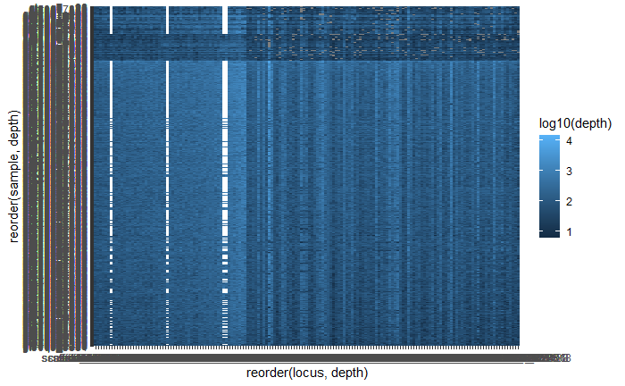

```r
genos_locs_ind_filtered  %>%
  unite(gtseq_run, id, col = "sample", remove = F) %>%
  ggplot(aes(x = reorder(locus, depth), y = reorder(sample, depth), fill = log10(depth))) +
  geom_tile()
```

## self-assignment

Doing a sanity check with the reference baseline

```r
# first make integers of the alleles
alle_idxs <- genos_locs_ind_filtered %>%
  dplyr::select(gtseq_run, id, locus, gene_copy, allele) %>%
  group_by(locus) %>%
  mutate(alleidx = as.integer(factor(allele, levels = unique(allele)))) %>%
  ungroup() %>%
  arrange(gtseq_run, id, locus, alleidx) # rubias can handle NA's, so no need to change them to 0's
```

Add population information from metadata:

```r
# metadata for reference samples
meta1 <- readxl::read_xlsx("../data/BFAL_WGS_01_finalPlateMap.xlsx", sheet = "combinedPlate1And2SamplePops")

samplelist <- read_csv("../data/gtseq5_samplelist.csv") %>%
  mutate(gtseq_run = "gtseq5") %>%
  rename(id = sample)
metadata <- samplelist %>%
  left_join(., meta1, by = c("Sample_ID" = "ind_ID")) %>%
  mutate(population = ifelse(!is.na(pop), pop, population)) %>%
  mutate(population = ifelse(is.na(population), "bycatch", population)) %>%
  select(-pop)

# just reference samples
ref_samples <- metadata %>%
  filter(!population %in% c("bycatch","NTC")) %>%
  select(Sample_ID, gtseq_run, id, population) %>%
  left_join(., genos_locs_ind_filtered, by = c("gtseq_run", "id"))

ref_pops <- ref_samples %>%
  select(gtseq_run, id, Sample_ID, population) %>%
  unique()
```

```r
alle_idxs %>%
  filter(gtseq_run == "gtseq5") %>%
  select(id) %>%
  unique() %>%
  inner_join(., ref_pops) %>%
  left_join(., alle_idxs)
```

| id | gtseq_run | Sample_ID | population | locus | gene_copy | allele | alleidx |
| --- | --- | --- | --- | --- | --- | --- | --- |
| s193 | gtseq5 | BFAL16-0373 | Laysan | scaffold_0_4543438 | 1 | GGA | 1 |
| s193 | gtseq5 | BFAL16-0373 | Laysan | scaffold_0_4543438 | 2 | GGA | 1 |
| s193 | gtseq5 | BFAL16-0373 | Laysan | scaffold_1_5556176 | 2 | CT | 1 |
| s193 | gtseq5 | BFAL16-0373 | Laysan | scaffold_1_5556176 | 1 | CC | 2 |
| s193 | gtseq5 | BFAL16-0373 | Laysan | scaffold_10_1333563 | 1 | G | 1 |
| s193 | gtseq5 | BFAL16-0373 | Laysan | scaffold_10_1333563 | 2 | A | 2 |
| s193 | gtseq5 | BFAL16-0373 | Laysan | scaffold_102_694013 | 2 | T | 1 |
| s193 | gtseq5 | BFAL16-0373 | Laysan | scaffold_102_694013 | 1 | C | 2 |
| s193 | gtseq5 | BFAL16-0373 | Laysan | scaffold_1050_36334 | 1 | T | 1 |
| s193 | gtseq5 | BFAL16-0373 | Laysan | scaffold_1050_36334 | 2 | T | 1 |

[output cut: 990 more lines]

```r
# format for rubias
reference <- alle_idxs %>%
  inner_join(., ref_pops) %>%
  select(-allele, -gtseq_run, -id) %>%
  select(population, Sample_ID, everything()) %>%
  rename(collection = population, indiv = Sample_ID)
```

```r
# make two-col format
ref_two_col <- reference %>%
  unite("loc", 3:4, sep = ".") %>%
  pivot_wider(names_from = loc, values_from = alleidx) %>%
  mutate(repunit = collection) %>%
  mutate(sample_type = "reference") %>%
  select(sample_type, repunit, collection, everything()) %>% # modify repunit info for Whale-Skate and Tern, which should be a single repunit for the French Frigate Shoals
  mutate(repunit = ifelse(collection %in% c("Tern", "Whale-Skate"), "FFS", repunit))
```

```r
# self-assignment
baseline_assign <- rubias::self_assign(ref_two_col, gen_start_col = 5)
```

```
Summary Statistics:

129 Individuals in Sample

159 Loci: scaffold_0_4543438.1, scaffold_1_5556176.2, scaffold_10_1333563.1, scaffold_102_694013.2, scaffold_1050_36334.1, scaffold_1053_177405.1, scaffold_1078_116737.1, scaffold_11_3057945.1, scaffold_115_2200290.1, scaffold_116_1932131.1, scaffold_116_386790.2, scaffold_12_5002902.1, scaffold_121…

6 Reporting Units: Laysan, Lehua, Midway, FFS, Kure, Torishima

7 Collections: Laysan, Lehua, Midway, Tern, Whale-Skate, Kure, Torishima

0.54% of allelic data identified as missing
```

```r
top_assign <- baseline_assign %>%
  group_by(indiv) %>%
  slice_max(., order_by = scaled_likelihood)

top_assign %>% # top assignment for each sample
  ggplot(aes(x = scaled_likelihood)) +
  geom_histogram()
```

[output not shown]

[output not shown]

11 mis-assignments, but only 6 with a scaled-likelihood > 0.9 and all of those are within the Hawaiian colonies.

Pretty good!

So overall:

| indiv | collection | repunit | inferred_collection | inferred_repunit | scaled_likelihood | log_likelihood | z_score | n_non_miss_loci | n_miss_loci | missing_loci |
| --- | --- | --- | --- | --- | --- | --- | --- | --- | --- | --- |
| BFAL-KURE-01 | Kure | Kure | Kure | Kure | 0.9997048 | -149.8666 | -1.857161276 | 154 | 0 |  |
| BFAL-KURE-02 | Kure | Kure | Kure | Kure | 0.9999998 | -129.5627 | 0.792768490 | 154 | 0 |  |
| BFAL-KURE-03 | Kure | Kure | Kure | Kure | 0.9975411 | -144.6193 | -1.172318900 | 154 | 0 |  |
| BFAL-KURE-04 | Kure | Kure | Kure | Kure | 1.0000000 | -132.0570 | 0.322540093 | 153 | 1 |  |
| BFAL-KURE-05 | Kure | Kure | Kure | Kure | 1.0000000 | -127.9614 | 1.001754801 | 154 | 0 |  |
| BFAL-KURE-06 | Kure | Kure | Kure | Kure | 0.9999721 | -143.9748 | -1.088197666 | 154 | 0 |  |
| BFAL-KURE-07 | Kure | Kure | Kure | Kure | 0.9999999 | -136.9772 | -0.174919973 | 154 | 0 |  |
| BFAL-KURE-08 | Kure | Kure | Midway | Midway | 0.9777631 | -126.0455 | 1.542396815 | 154 | 0 |  |
| BFAL-KURE-09 | Kure | Kure | Kure | Kure | 0.9986069 | -130.2705 | 0.700390144 | 154 | 0 |  |
| BFAL-KURE-10 | Kure | Kure | Kure | Kure | 0.9999932 | -138.4515 | -0.367333950 | 154 | 0 |  |

[output cut: 119 more lines]

129 samples in the reference baseline (10 dropped out bec of missing data).

86% of samples correctly assigned at 90% scaled likelihood.

```r
111/129
```

```
[1] 0.8604651
```

If we only look at samples that were assigned at > 90% threshold:

```r
top_assign %>%
  filter(scaled_likelihood > 0.9)
```

| indiv | collection | repunit | inferred_collection | inferred_repunit | scaled_likelihood | log_likelihood | z_score | n_non_miss_loci | n_miss_loci | missing_loci |
| --- | --- | --- | --- | --- | --- | --- | --- | --- | --- | --- |
| BFAL-KURE-01 | Kure | Kure | Kure | Kure | 0.9997048 | -149.8666 | -1.857161276 | 154 | 0 |  |
| BFAL-KURE-02 | Kure | Kure | Kure | Kure | 0.9999998 | -129.5627 | 0.792768490 | 154 | 0 |  |
| BFAL-KURE-03 | Kure | Kure | Kure | Kure | 0.9975411 | -144.6193 | -1.172318900 | 154 | 0 |  |
| BFAL-KURE-04 | Kure | Kure | Kure | Kure | 1.0000000 | -132.0570 | 0.322540093 | 153 | 1 |  |
| BFAL-KURE-05 | Kure | Kure | Kure | Kure | 1.0000000 | -127.9614 | 1.001754801 | 154 | 0 |  |
| BFAL-KURE-06 | Kure | Kure | Kure | Kure | 0.9999721 | -143.9748 | -1.088197666 | 154 | 0 |  |
| BFAL-KURE-07 | Kure | Kure | Kure | Kure | 0.9999999 | -136.9772 | -0.174919973 | 154 | 0 |  |
| BFAL-KURE-08 | Kure | Kure | Midway | Midway | 0.9777631 | -126.0455 | 1.542396815 | 154 | 0 |  |
| BFAL-KURE-09 | Kure | Kure | Kure | Kure | 0.9986069 | -130.2705 | 0.700390144 | 154 | 0 |  |
| BFAL-KURE-10 | Kure | Kure | Kure | Kure | 0.9999932 | -138.4515 | -0.367333950 | 154 | 0 |  |

[output cut: 107 more lines]

```r
111/117
```

```
[1] 0.9487179
```

Which would be 95% accurate assignment.

Quick look at z-scores:

```r
top_assign %>%
  ggplot(aes(z_score)) +
  geom_histogram()
```

[output not shown]

```r
top_assign %>%
  filter(z_score < -3)
```

| indiv | collection | repunit | inferred_collection | inferred_repunit | scaled_likelihood | log_likelihood | z_score | n_non_miss_loci | n_miss_loci | missing_loci |
| --- | --- | --- | --- | --- | --- | --- | --- | --- | --- | --- |
| BFAL21-0173 | Laysan | Laysan | Laysan | Laysan | 1 | -237.3293 | -7.159539 | 153 | 1 |  |

```r
NA
```

Maybe a different species accidentally? I can double-check the sample number with metadata that Jessie sent. Other than that, things are looking good to proceed with mixture assignment.

Output genotypes/data for evaluating the loci in `10-locus-summary-and-eval.Rmd`

```r
# save outputs
tmp %>%
  write_csv("csv_outputs/two_column_dataset.csv")

genos_locs_ind_filtered %>%
  write_rds("../data/processed/genotypes_loc_ind_filtered.rds")

alle_idxs %>%
  write_rds("../data/processed/alle_idxs.rds")

reference %>%
  write_rds("../data/processed/reference_genos.rds")
```